# FINAL_CAPSTONE_PROJECT

| **THE MUTUAL FUNDS OFFERED BY MAJOR SPANISH BANKS GENERATES ALFA?** **JAVIER CHOLBI DOBLADO** |  |
| --- | --- |

## Applied Data Science Capstone by IBM/Coursera

## Table of contents

- Introduction: Business Problem
- Data
- Methodology
- Analysis
- Results and Discussion
- Conclusion

# Introduction: Business Problem

In this project we will try to analyse if the "active" mutual funds offered by the major spanish banks **generates alpha (obtain better results vs benchmark) in a consistent way along the time**, in other words if it's worth to pay highers commisions for buy this mutual funds before to buy ETFs.

Our main objective its to **show with data if the active management in the mutual funds industry works properly** and try to answer several questions like:

- Can the active mutual funds management by the major banks generates alfa?
- Its better the performance in the active management vs the pasive management?

We will use our data science powers to generate a stadistical and visual analyse using some machine learning techniques as Linear and Multiple Regression.

# Data and packages

Based on definition of our problem, data that will influence in our analysis are:

- End of day historical prices of main mutual funds offered by spanish major banks from 2001 until now.
- End of day historical prices of main index, for Europe market: EuroStoxx 50 Index.

The source of all the data used in the analysis its provided by Bloomberg across xlsx files.

# Methodology

**In this project we will direct our efforts in two principal axis:**

- Make a deep statistical analysis to show if there are enough evidences to affirm if spanish mutual fund management by major banks are ables to generate alfa across the time and not only in a shor period of time.
- Make a deep visualization job using different kind of charts to ilustrate and majke easy to understand our conclusions.

**Speaking about statistical techniques we are focus in:**

- Correlation historical analysis
- Pearson coeficient
- Matrix Correlation
- Histogram analysis
- Value at Risk
- Linear Regression
- Tracking Error Ratio
- Sharpe Ratio
- Alfa Ratio

**Speaking about visualization we are going to use:**

- Frequency histograms
- Boxplots charts
- Scatter plots
- Bubble plots
- Area plots

**Speaking about Data Science Tecniques we are going to use:**

- Data Wrangling to clean the differents datasets.
- Data Analyst
- Data Modelling

**The analysis has 3 parts:**

- In first place clean the dataset using data wrangling techniques and explore the data using the descriptive statistical.
- Second place, draw differents plots to understand better the information and try to see initials answer to resolve our problems.
- Last part, use a complex stadistical techniques to make a deep analyisis that allow us to get right conclussions based on data.

# Analysis:

## 0. Data Wranggling

- We need to clean the dataset and drop the rows with NaN values,this it's extremely important to avoid strange results or outlier values. In this specific case there is no NaN values in the differents datasets...

## 1. Description information and price evolution about mutual funds in differents periods of time:

## 3. Five Years: We are going to make all the statistical analysis with this dataset

|  | EURO STOXX 50 | BBVA Equity Europe | POPULAR Equity Europe | BANKINTER Equity Europe | SANTANDER Equity Europe | BANKIA Equity Europe | SABADELL Equity Europe | CAIXABANK Equity Europe | RENTA4 Equity Europe |
| --- | --- | --- | --- | --- | --- | --- | --- | --- | --- |
| count | 1455.000000 | 1455.000000 | 1455.000000 | 1455.000000 | 1455.000000 | 1455.000000 | 1455.000000 | 1455.000000 | 1455.000000 |
| mean | 106.112509 | 102.002247 | 110.795466 | 99.385622 | 112.437137 | 107.443459 | 105.465622 | 110.231213 | 125.024887 |
| std | 7.249717 | 6.248570 | 8.002966 | 8.039338 | 9.393818 | 7.748923 | 6.409257 | 8.461517 | 16.110440 |
| min | 86.212609 | 85.430575 | 89.941731 | 80.154345 | 88.252796 | 86.729643 | 88.997025 | 88.287729 | 96.604173 |
| 25% | 100.078803 | 97.799600 | 103.306685 | 92.520953 | 103.605768 | 100.351049 | 99.998105 | 102.220813 | 110.435112 |
| 50% | 106.286266 | 101.620995 | 111.311250 | 100.651119 | 113.838489 | 107.507482 | 105.223629 | 110.628466 | 121.136936 |
| 75% | 111.965584 | 105.655618 | 118.294537 | 104.223965 | 120.920629 | 114.549026 | 111.214672 | 118.036046 | 140.465566 |
| max | 123.151496 | 119.578448 | 124.179538 | 120.247856 | 127.942755 | 121.339517 | 118.465386 | 124.963516 | 152.405700 |

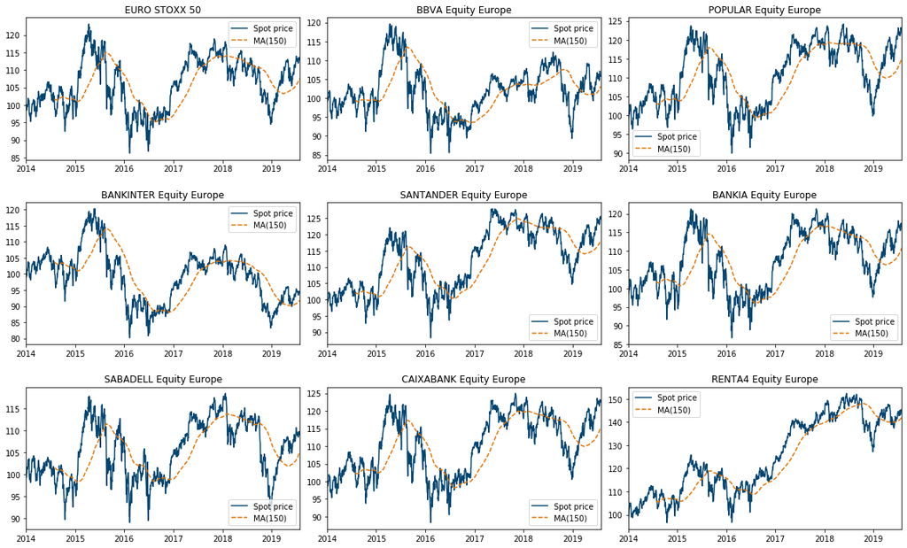

## 3.1 All the Indices vs Eurostoxx 50

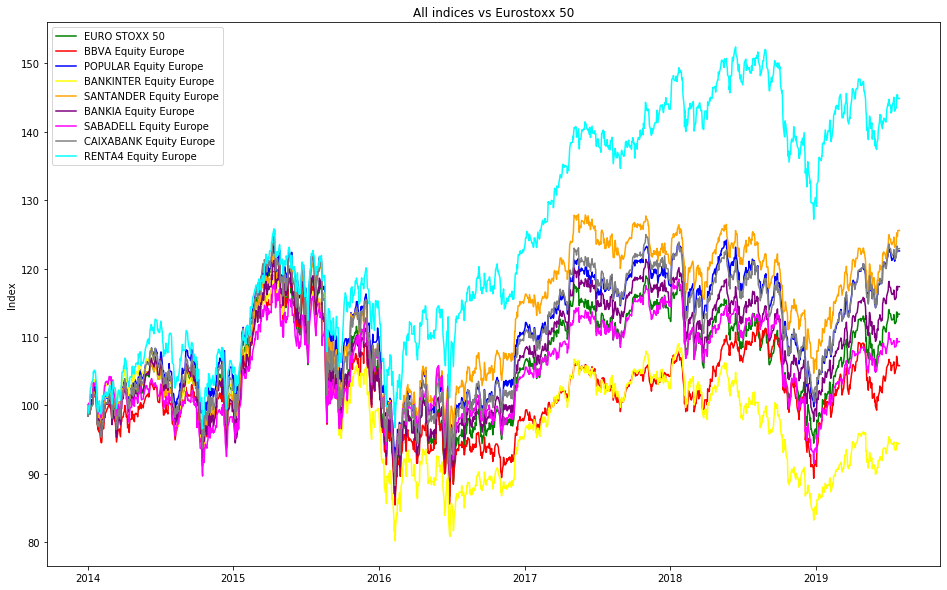

- We are going to focus all the analysis in the 5 year term. This its a reasonable window for the active management inside the mutual fund industries...all the calculation are made with this temporal horizon. In this chart we can compare the differents funds in index numbers (january 2014=100), We can see that all the funds have more and less the same behaviour except the RENTA 4 fund.
- Renta 4 has a incredible generation of alfa during this period, there are other funds with positive alfa as SANTANDER but this its not enought to affirm that both funds are a good active funds...we need to examine his stadistical behaviour...

# 2. Transform the 5Y dataset in daily returns to make the stadistical analyst

|  | DATES | EURO STOXX 50 | BBVA Equity Europe | POPULAR Equity Europe | BANKINTER Equity Europe | SANTANDER Equity Europe | BANKIA Equity Europe | SABADELL Equity Europe | CAIXABANK Equity Europe | RENTA4 Equity Europe |
| --- | --- | --- | --- | --- | --- | --- | --- | --- | --- | --- |
| 1 | 2014-01-02 | -0.015783 | -0.009649 | -0.010056 | -0.009392 | -0.012082 | -0.015787 | -0.007195 | -0.015890 | -0.011445 |
| 2 | 2014-01-03 | 0.004739 | 0.005317 | 0.005437 | 0.005696 | 0.005483 | 0.005707 | 0.010270 | 0.004594 | 0.000000 |
| 3 | 2014-01-06 | -0.001714 | -0.002084 | 0.000000 | 0.000684 | -0.000006 | -0.001763 | -0.000376 | -0.001892 | 0.012374 |
| 4 | 2014-01-07 | 0.013619 | 0.008518 | 0.011826 | 0.012952 | 0.008804 | 0.014326 | 0.008791 | 0.013599 | 0.019529 |
| 5 | 2014-01-08 | -0.000096 | 0.000418 | 0.002486 | 0.003869 | -0.000406 | 0.001613 | 0.004722 | -0.000290 | 0.005260 |

|  | EURO STOXX 50 | BBVA Equity Europe | POPULAR Equity Europe | BANKINTER Equity Europe | SANTANDER Equity Europe | BANKIA Equity Europe | SABADELL Equity Europe | CAIXABANK Equity Europe | RENTA4 Equity Europe |
| --- | --- | --- | --- | --- | --- | --- | --- | --- | --- |
| count | 1454.000000 | 1454.000000 | 1454.000000 | 1454.000000 | 1454.000000 | 1454.000000 | 1454.000000 | 1454.000000 | 1454.000000 |
| mean | 0.000144 | 0.000088 | 0.000188 | 0.000012 | 0.000206 | 0.000165 | 0.000107 | 0.000200 | 0.000296 |
| std | 0.010781 | 0.009861 | 0.009823 | 0.010087 | 0.009890 | 0.010474 | 0.009538 | 0.010730 | 0.009080 |
| min | -0.086169 | -0.084448 | -0.070514 | -0.087759 | -0.077100 | -0.083487 | -0.089760 | -0.086153 | -0.078490 |
| 25% | -0.005120 | -0.004373 | -0.004212 | -0.004535 | -0.004195 | -0.004778 | -0.004337 | -0.004879 | -0.003916 |
| 50% | 0.000255 | 0.000163 | 0.000000 | 0.000083 | 0.000169 | 0.000197 | 0.000368 | 0.000183 | 0.000247 |
| 75% | 0.005465 | 0.005070 | 0.005018 | 0.004979 | 0.005116 | 0.005210 | 0.004848 | 0.005386 | 0.005145 |
| max | 0.047056 | 0.047333 | 0.040225 | 0.043944 | 0.044879 | 0.048286 | 0.043944 | 0.047381 | 0.035487 |

- We need to transform the dataset into daily returns to analyse the statistical metrics, if we make the analysis directly with the number we are making a big mistake and wasting our time...
- In this table we can see the mean, differents percentiles and the standard desviation.

# 3. Correlation Eurostoxx 50 vs Active Mutual Funds (5 Year Window)

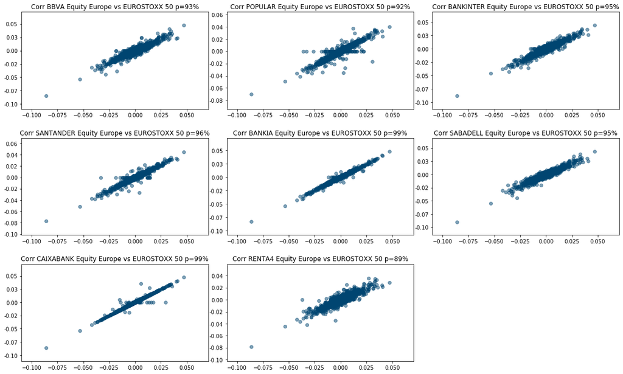

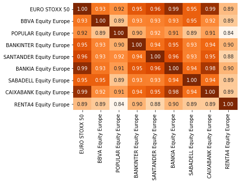

- The correlation between the Euro Stoxx 50 and the rest of the mutual funds are very high. The pearson ratio is higher than 90% for the vast majority, this factor its very negative in our expectatives to find a good active funds, because if the movements in the prices are very similar its very complicated to have better results vs Benchmark...the unique fund that we can consider with some difference in the returns movements its RENTA4 but we need to continue the analysis...

# 4. Evolution in the correlation a long time. ¿It's consistent the correlation ratios?

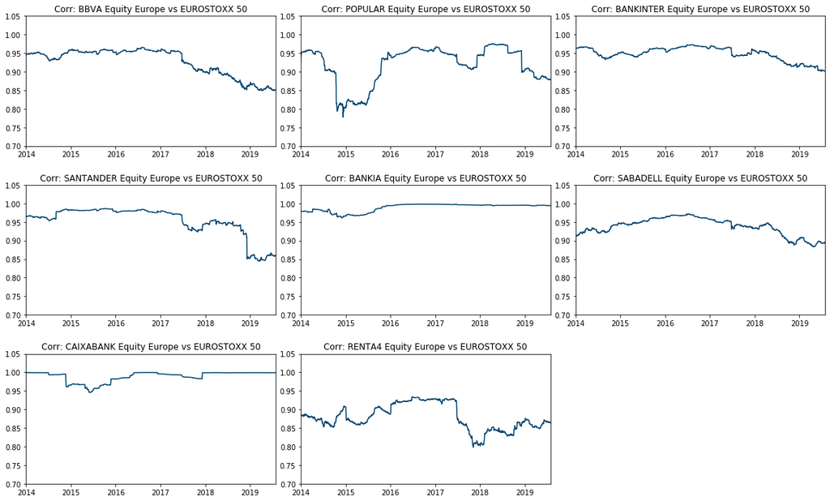

- In this chart we can see the correlation not only in a point of time but in a historical range...we can see more and less the same conclusion from the previous step, but here there are two funds (SANTANDER and RENTA4) that can have at least during several time less correlations, this it's good in terms of active manegement.

# 5.Histogram returns and Value at Risk (VAR 95%)

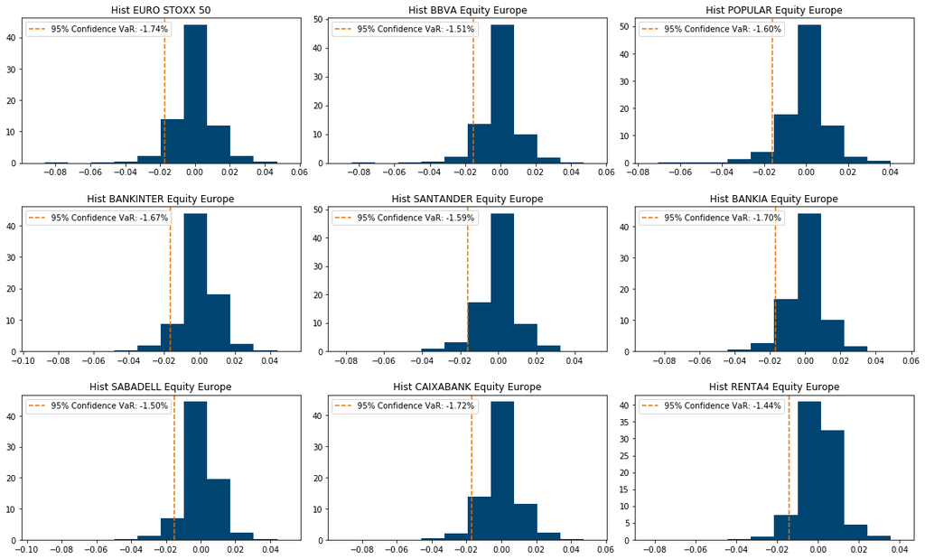

*The frequency histogram are very similar in all the funds except in the RENTA4 fund, this fund has more positive tails than the others distributions and at the same time has a lower VAR ratio...this suppose a important difference and its a very important caracteristic in the active mutual funds...

# 6. Boxplot (How it's the behavior of the returns? Tend to zero?)

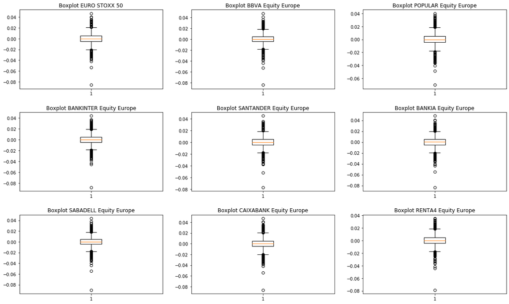

*The boxplot chart it's very useful to see how is the daily returns behavior. In our analysis we can see that almost all the funds has the same returns with a very similar interquartile range...this its very negative in terms of find active funds...due to his behaviour its the same than the benchmark index...

# 7. Linear Regression between Eurostoxx 50 vs Active Mutual Funds

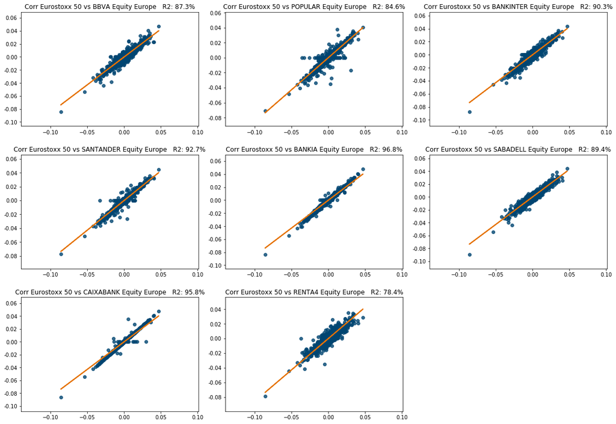

*All the funds have a very high correlation and R2 ratio, and we can see clearly that the movements in his returns are very similar at the Euro Stoxx 50 daily returns...this give an idea about the active management grade...only the RENTA4 has a ratio lower than 80%.

# 8. Tracking Error Eurostoxx 50 vs Active Mutual Funds

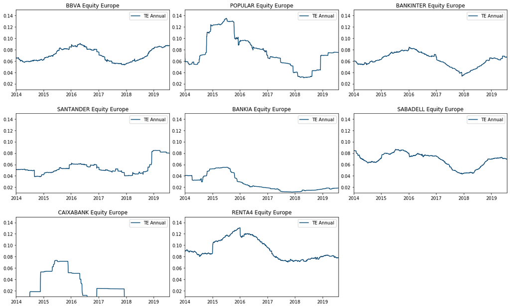

# 9. Sharpe Ratio

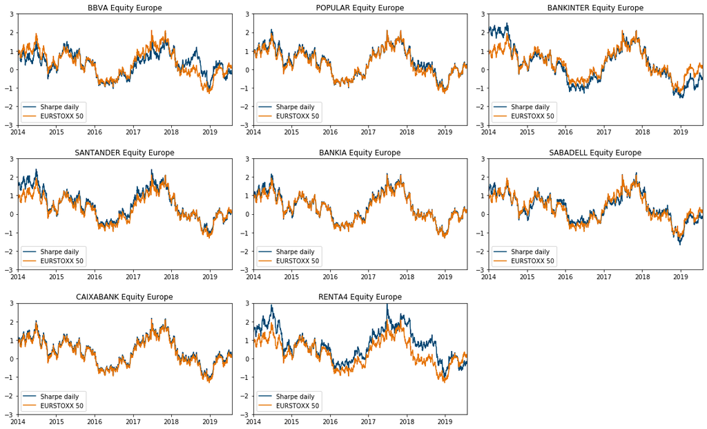

# 10. Alfa Analysis

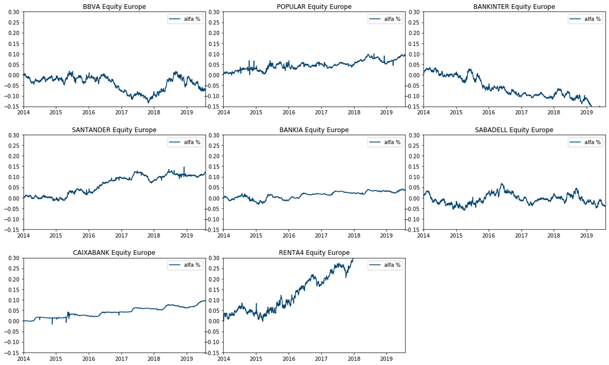

# 11. Mutual Fund size vs Alfa

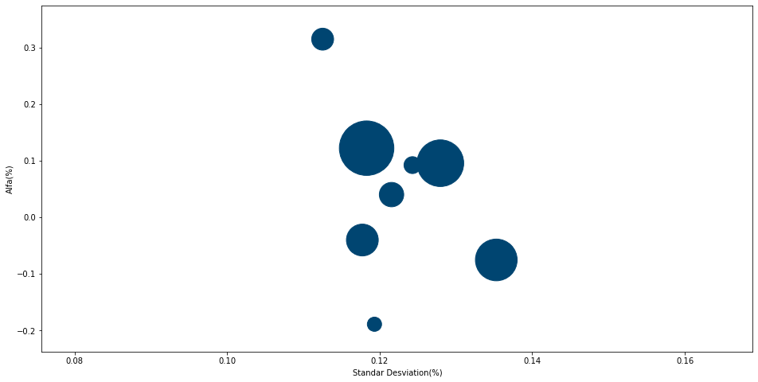

- There is no lineal relation between volume and alfa generation and we can't find clearly relationships between the risk and the alfa generation, so the key factor is the chief economist knowledge abaout the differents sector and corporates

# Results and Discussion

## Summary Table:

After our analysis we can see the results in the summary table:

|  | Mutual Fund | Alfa | Standar-Desviation | Sharpe-Ratio | Track-Error-Ratio | Pearson-Ratio | R2-Ratio | VAR95%-Ratio |
| --- | --- | --- | --- | --- | --- | --- | --- | --- |
| 0 | BBVA Equity Europe | -0.075278 | 0.135290 | -0.244579 | 0.087285 | 0.934266 | 87.3 | -1.514373 |
| 1 | POPULAR Equity Europe | 0.092391 | 0.124299 | 0.187279 | 0.074894 | 0.919829 | 84.6 | -1.603305 |
| 2 | BANKINTER Equity Europe | -0.188986 | 0.119315 | -0.550266 | 0.066357 | 0.951067 | 90.3 | -1.668539 |
| 3 | SANTANDER Equity Europe | 0.122363 | 0.118286 | 0.105925 | 0.079787 | 0.963157 | 92.7 | -1.588134 |
| 4 | BANKIA Equity Europe | 0.040247 | 0.121554 | 0.139839 | 0.018571 | 0.990355 | 96.8 | -1.695701 |
| 5 | SABADELL Equity Europe | -0.040060 | 0.117728 | -0.209338 | 0.068787 | 0.945945 | 89.4 | -1.499833 |
| 6 | CAIXABANK Equity Europe | 0.095792 | 0.127955 | 0.208462 | 0.006922 | 0.986935 | 95.8 | -1.716250 |
| 7 | RENTA4 Equity Europe | 0.315127 | 0.112520 | -0.285242 | 0.077958 | 0.893857 | 78.4 | -1.435818 |

## Main Results:

**BBVA, SABADELL, BANKINTER:**

- This fund in the 5 year horizon dont seems to generate alfa, normally his returns are very similiar than the benchmark returns even has a worst behaviuor (alfa ratio negative).
- In other hand the pearson correlation with the benchmark is so high (higher than 90%) and the R2 ratio is in a similar level.
- The Value at risk its almost equal vs Benchmark and happend the same with the return histogram.
- The track error is more and less a 6% and the sharpe ratio is normally worst than benchmark.

# Conclusion